# ST_diversity

Sean Swift

January 30, 2020

### Import sequencing data into phyloseq for visualization

```r
library(phyloseq)
library(dplyr)
```

```r
library(ggplot2)
# Following https://joey711.github.io/phyloseq/plot_richness-examples.html

# source the function 'make_phyloseq' because I don't always remember the syntax
setwd("~/Documents/Bioinformatics/Projects/SuperTransect/Analysis/exploration/R_notebook/")

source("src/make_phyloseq.R")
ST_16S <- readRDS("data/processed/cleaned/ST_16S.rds")

ST_16S_phy <- make_phyloseq(ST_16S)


# Add in our new spatial metadata (also remove controls)
# set rownames and update the phyloseq object
spatial_meta <- readRDS("data/interim/field_meta.rds")

rownames(spatial_meta) <- spatial_meta[[1]]
spatial_meta<- spatial_meta[-1]

# add correct levels for transects
spatial_meta$transect_name %>% unique
```

```
## [1] "Marine"          "STSummit"        NA                "STAboveFalls"
## [5] "STDrumRoadMakai" "STDrumRoadMauka" "STEstuary"       "STFalls"
## [9] "STGardens"
```

```r
transect_levels <- c(
  "Marine" ,
  "STEstuary",
  "STGardens",
  "STFalls",
  "STAboveFalls",
  "STDrumRoadMakai",
  "STDrumRoadMauka",
  "STSummit"
  )


spatial_meta$transect_name <- factor(spatial_meta$transect_name, levels = transect_levels )

sample_data(ST_16S_phy) <- spatial_meta
```

## Check sample totals again

Some samples were lost to the pipeline. Also, looks like we’re missing marine water samples… The only marine samples that are in the library correspond to the samples sent for MS analysis.

```r
## Actual sample replication across sample types

# Marine samples
ST_16S$metadata %>% filter(site_type == "Core Waimea") %>% group_by(sample_type) %>% summarise(count = n())
```

```
## # A tibble: 3 x 2
##   sample_type count
##   <chr>       <int>
## 1 CCA            34
## 2 Coral          36
## 3 Limu           24
```

```r
# Terrestrial samples
ST_16S$metadata %>% filter(site_type ==  "Transect") %>% group_by(sample_type) %>% summarise(count = n())
```

```
## # A tibble: 8 x 2
##   sample_type    count
##   <chr>          <int>
## 1 Drosophila        39
## 2 Mosquito          34
## 3 PlantRoot         44
## 4 PlantShoot         8
## 5 Sediment          57
## 6 SoilDeep          56
## 7 SoilShallow       59
## 8 WaterNonSaline    68
```

## Typical host site

Transect Start/Middle/End Sites. 0m, 400m, 800m. note: distance btwn start of one transect and end of previous transect not uniform

```r
ST_16S$metadata %>% filter(site_type == "Transect", site_name == "STGardens9") %>% group_by(site_name, sample_type) %>% summarise(sample_counts = n())
```

```
## # A tibble: 6 x 3
## # Groups:   site_name [1]
##   site_name  sample_type    sample_counts
##   <chr>      <chr>                  <int>
## 1 STGardens9 Mosquito                   4
## 2 STGardens9 PlantRoot                  3
## 3 STGardens9 Sediment                   1
## 4 STGardens9 SoilDeep                   1
## 5 STGardens9 SoilShallow                1
## 6 STGardens9 WaterNonSaline             1
```

## Typical environmental site

Transect ‘filler’ sites. Sites at 100m, 200m, 300m, 500m, 600m, 700m. These were sampled for environmental samples (water, soil, sediment), but not hosts. note: mosquitoes are scattered around unevenly, same with drosophila, so they might pop up sometimes

```r
ST_16S$metadata %>% filter(site_type == "Transect", site_name == "STGardens2") %>% group_by(site_name, sample_type) %>% summarise(sample_counts = n())
```

```
## # A tibble: 5 x 3
## # Groups:   site_name [1]
##   site_name  sample_type    sample_counts
##   <chr>      <chr>                  <int>
## 1 STGardens2 Mosquito                   3
## 2 STGardens2 Sediment                   1
## 3 STGardens2 SoilDeep                   1
## 4 STGardens2 SoilShallow                1
## 5 STGardens2 WaterNonSaline             1
```

### Phyloseq Plots

Set up a nice ggplot theme

```r
# set up ggplot
theme_set(theme_bw())
pal = "viridis"
scale_colour_discrete <-  function(palname=pal, ...){
  scale_color_viridis_d(option = palname)
}
scale_fill_discrete <-  function(palname=pal, ...){
  scale_fill_viridis_d(option = palname)
}
```

## Set up a plotting option for our own diversity estimates

```r
# pipeline output alpha diversity
# reshape to match estimate_diversity output
alpha_div <- read.table("data/raw/sequence/all_alphaDiversity_97.summary", sep = "\t", header = T)
row.names(alpha_div) <- alpha_div$group
alpha_div <- alpha_div[-c(2,1)]

# slightly altered version of phyloseq plot_richness function
# allows custom diversity table named alpha_div with samples as rownames

source("src/s_plot_richness.R")
```

### Host vs. Non-host Alpha Diversity

Some plots showing differential diversity in hosts vs. environmenatl samples by habitat. Terrestrial hosts are less diverse than environmental samples. Marine hosts tend to have diversity more on par with environmental samples.

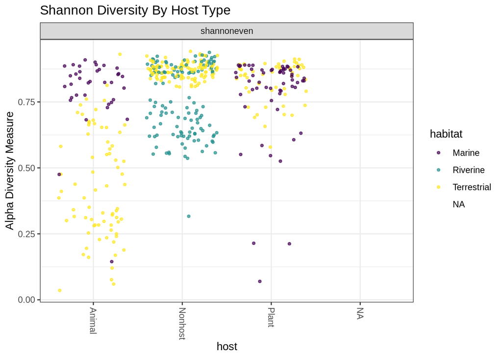

```r
# Shannon evenness by host type, colored by habitat
p <- s_plot_richness(ST_16S_phy, x = "host", measures ="shannoneven", title = "Shannon Diversity By Host Type", color = "habitat", custom = T)
p$layers <- p$layers[-1]
p + geom_point(size=1, alpha=0.7, position = "jitter")
```

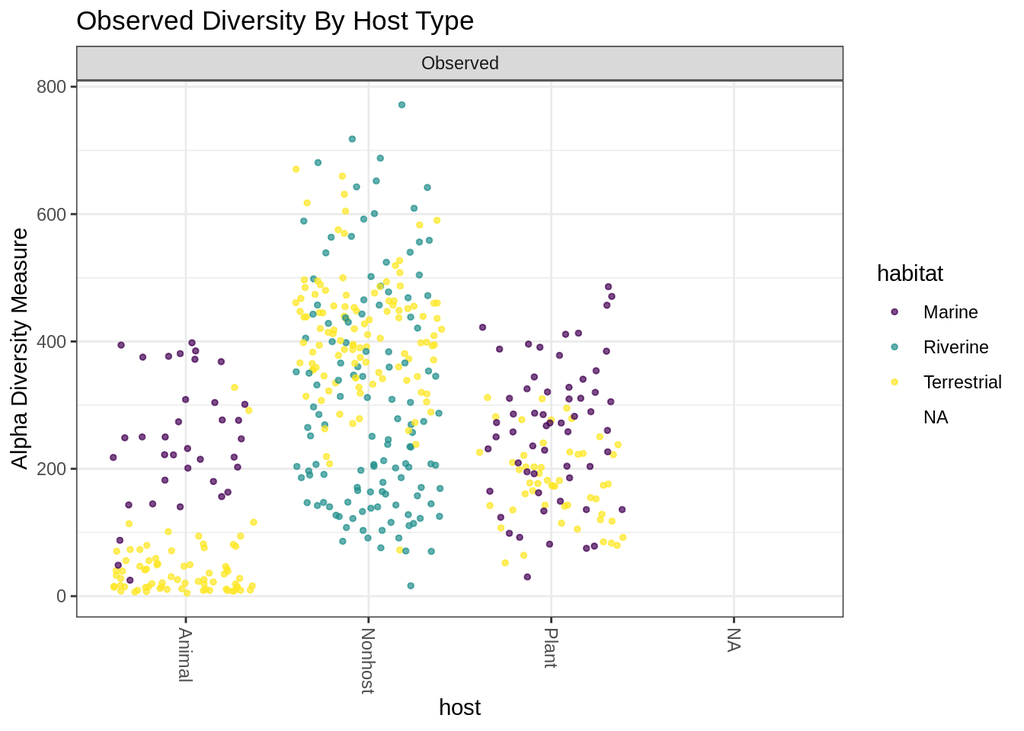

```r
# Observed by host type, colored by habitat
p <- plot_richness(ST_16S_phy, x = "host", measures ="Observed", title = "Observed Diversity By Host Type", color = "habitat")
p$layers <- p$layers[-c(1:2)]
p + geom_point(size=1, alpha=0.7, position = "jitter")
```

### Alpha-Diversity along Gradient: by sample type

Looking for trends in alpha diversity along the whole transect . The x-axis for these plots is the variable “shore_dist” (see ST_2_spatial.rmd). “shore_dist” is distance from the beach (river mouth). “site_order” will also indicate distance from shore, but by rank instead of distance.

I would say sample types are not varying in alpha diversity in an obvious way along supertransect. The high diversity in water samples at the summit is likely due to runoff. The stream was just a trickle in places and muddy/turbid, especially at the top.

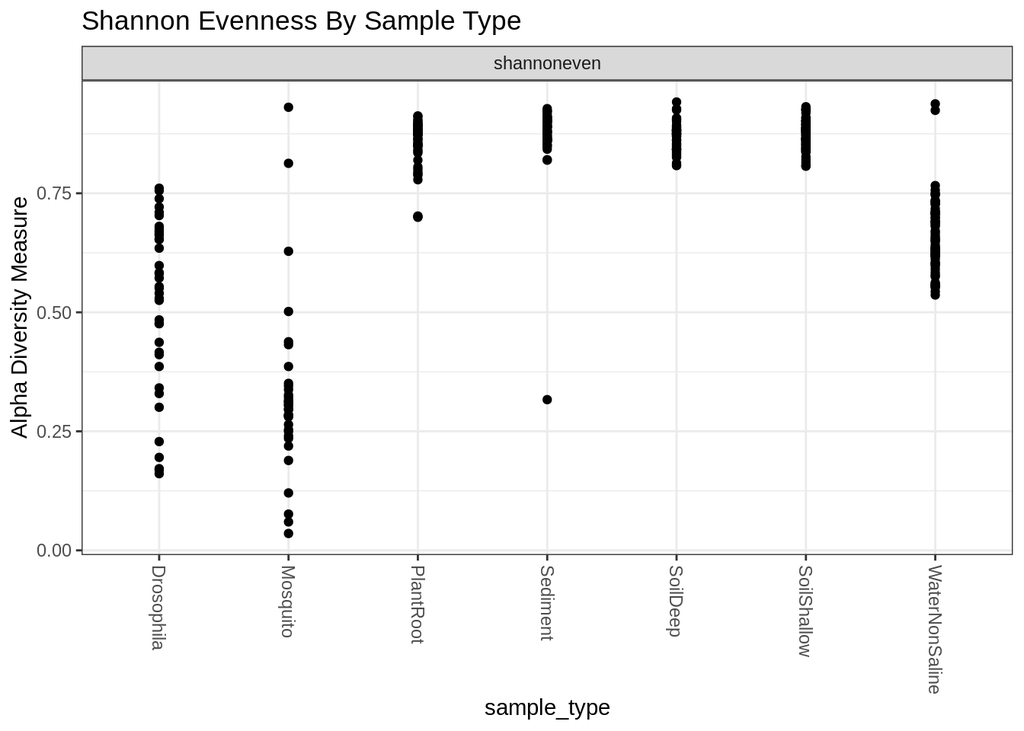

```r
# get rid of empty taxa
# get rid of plant shoots
# subset to just include terrestrial samples

ST  <- prune_taxa(taxa_sums(ST_16S_phy) > 0, ST_16S_phy)
ST  <- subset_samples(ST, habitat != "Marine")
ST  <- subset_samples(ST, sample_type != "PlantShoot")
s_plot_richness(ST, x = "sample_type", measures = "shannoneven", title = "Shannon Evenness By Sample Type")
```

```r
# plot alpha diversity along the gradient by sample type
sample_data(ST) %>% .$sample_type %>% unique()
```

```
## [1] "SoilShallow"    "PlantRoot"      "WaterNonSaline" "Sediment"
## [5] "SoilDeep"       "Mosquito"       "Drosophila"
```

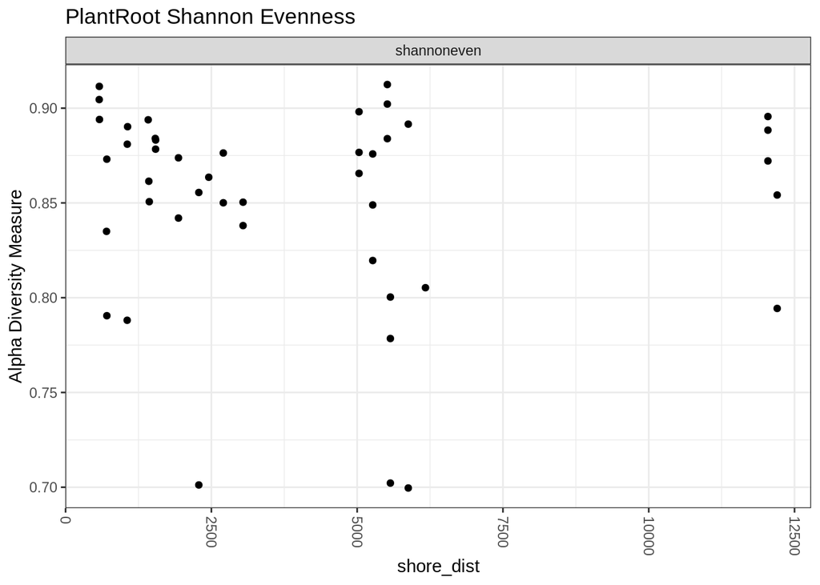

```r
# Host samples
ST_plant <- ST_plant <- subset_samples(ST, sample_type == "PlantRoot")
s_plot_richness(ST_plant, x = "shore_dist", measures ="shannoneven", title = "PlantRoot Shannon Evenness")
```

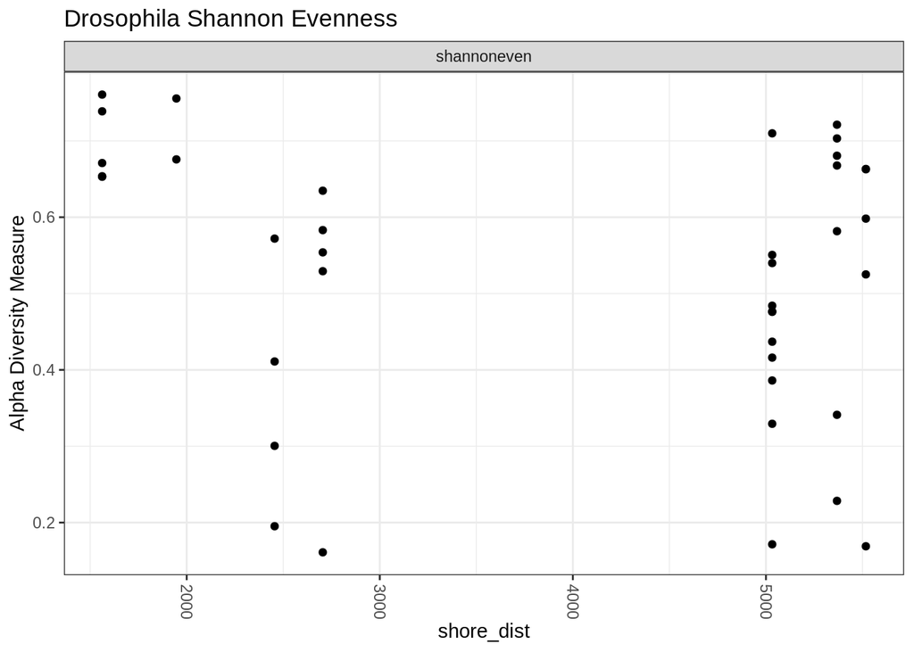

```r
rm(ST_plant)

ST_dros <- ST_dros <- subset_samples(ST, sample_type == "Drosophila")
s_plot_richness(ST_dros, x = "shore_dist", measures ="shannoneven", title = "Drosophila Shannon Evenness")
```

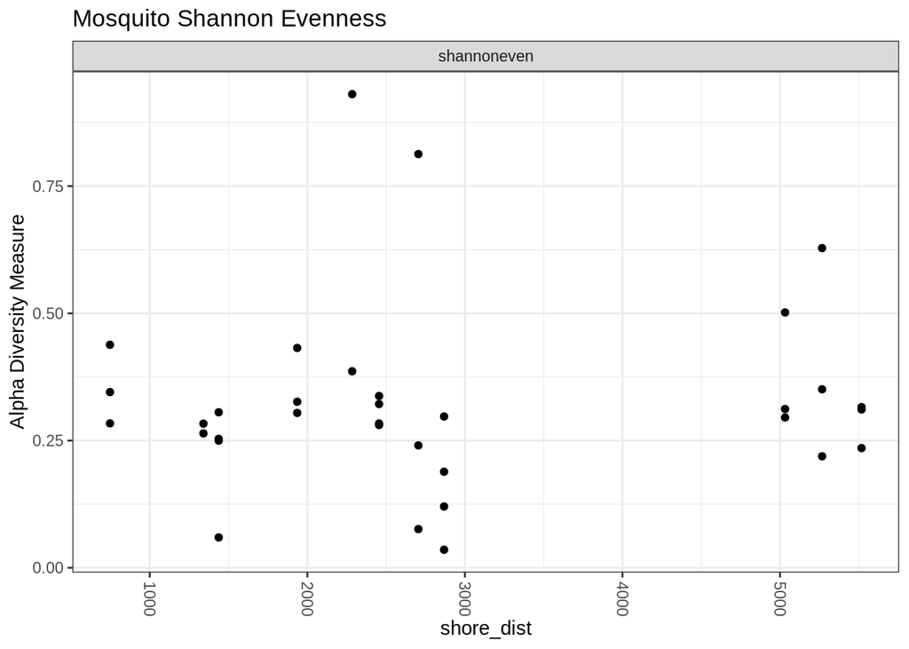

```r
rm(ST_dros)

ST_mos <- ST_mos <- subset_samples(ST, sample_type == "Mosquito")
s_plot_richness(ST_mos, x = "shore_dist", measures ="shannoneven", title = "Mosquito Shannon Evenness")
```

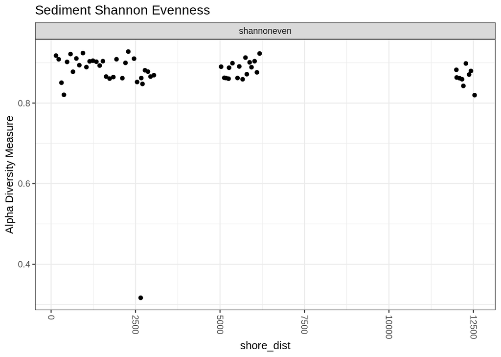

```r
rm(ST_mos)

# Environmental samples
ST_sed <- subset_samples(ST, sample_type == "Sediment")
s_plot_richness(ST_sed, x = "shore_dist", measures ="shannoneven", title = "Sediment Shannon Evenness")
```

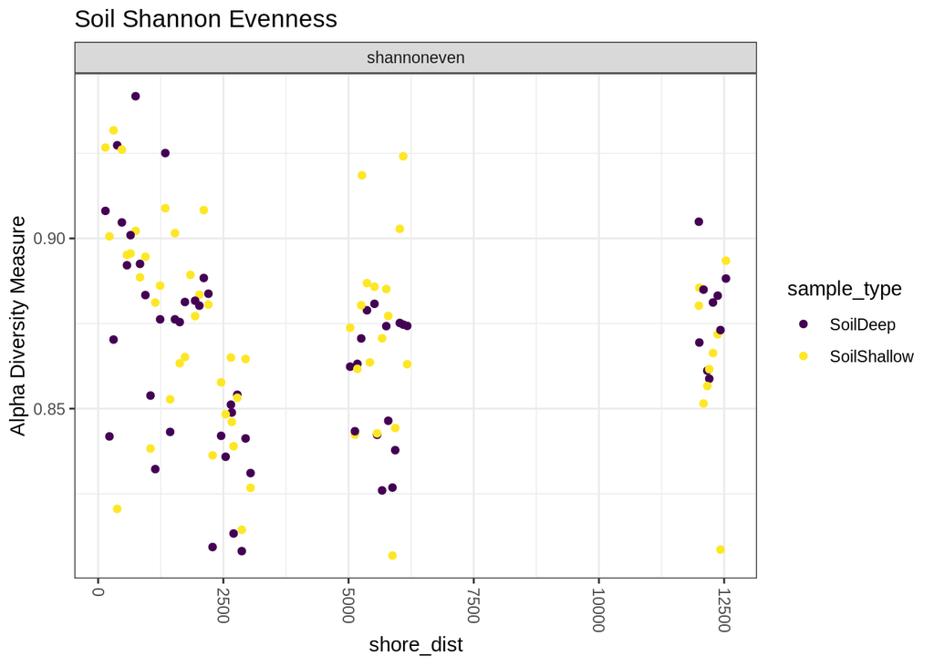

```r
rm(ST_sed)

ST_soil <- subset_samples(ST, sample_type %in% c( "SoilShallow","SoilDeep"))
s_plot_richness(ST_soil, x = "shore_dist", measures ="shannoneven", title = "Soil Shannon Evenness", color = "sample_type")
```

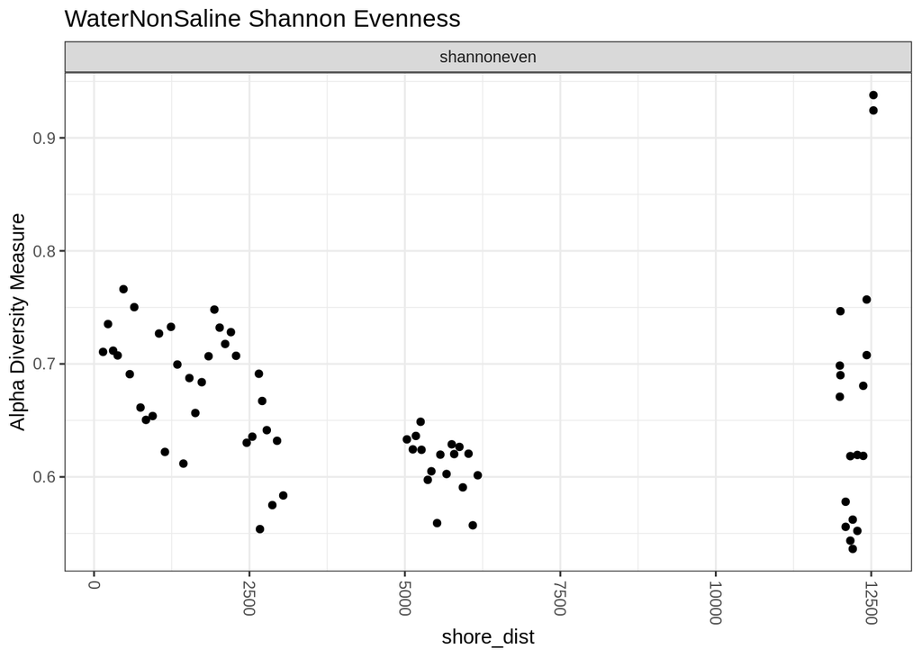

```r
rm(ST_soil)

ST_water <- subset_samples(ST, sample_type == "WaterNonSaline")
s_plot_richness(ST_water, x = "shore_dist", measures ="shannoneven", title = "WaterNonSaline Shannon Evenness")
```

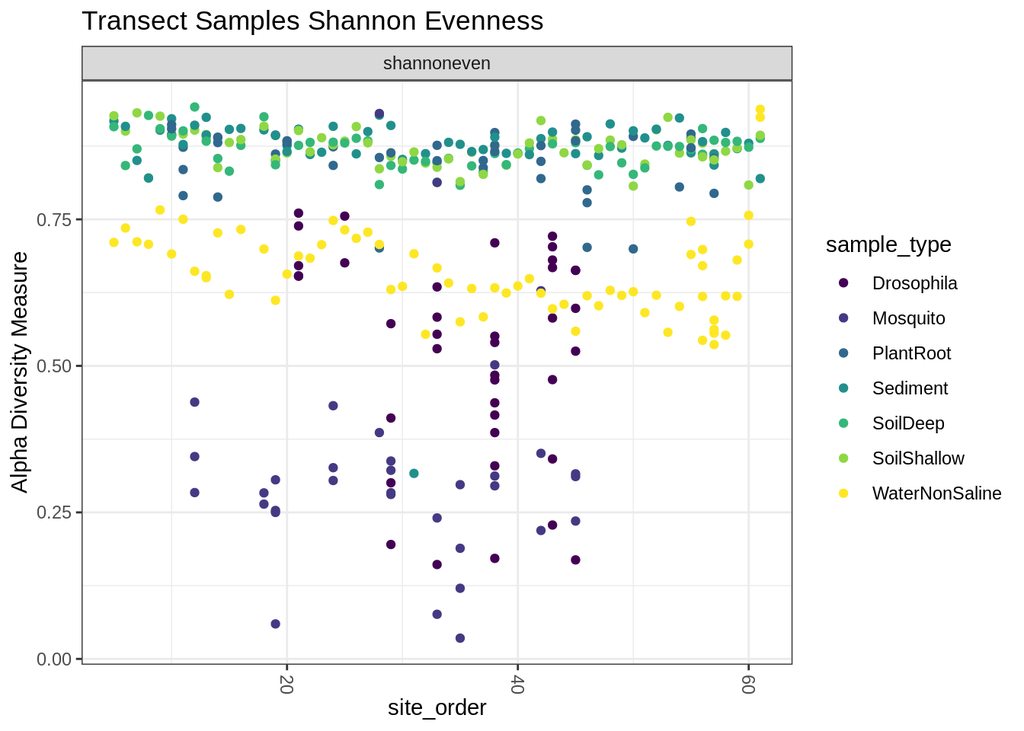

```r
rm(ST_water)

# plot alpha diversity along the gradient for all sample types along the transect
p <-  s_plot_richness(ST, x= "site_order", measures = c("shannoneven"), title = "Transect Samples Shannon Evenness", color = "sample_type")
p
```

### Alpha diversity grouped by transect

Are some transects (i.e. sections) more diverse than others? I merged OTU abundance for water+soil+sediment at each sampling site for this one. Not sure how valid it is to treat multiple sample types as one sample, but I’m going for it.

Each section of the transect is represented as a boxplot (1 = Estuary, 7 = Summit).

Spoiler: Looks like shannon diversity increases below the waterfall

```r
## Environmental Samples (taken every 100m)
# plot total alpha diversity, merging environmental samples at each sample site
ST_env <- subset_samples(ST, host == "Nonhost")
ST_env@sam_data$sample_type %>% unique()
```

```
## [1] "SoilShallow"    "WaterNonSaline" "Sediment"       "SoilDeep"
```

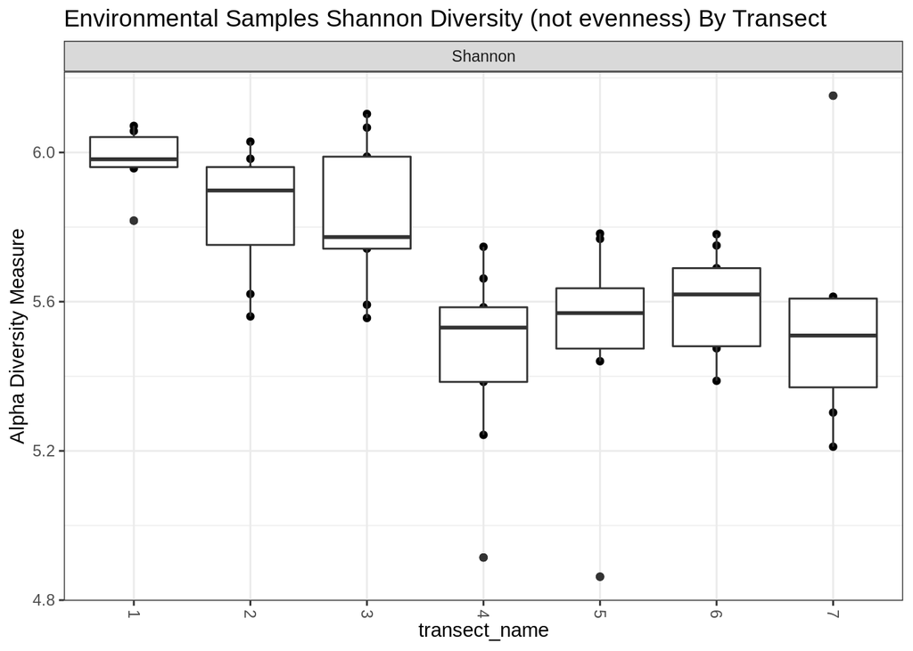

```r
# merge by site (i.e. soil, water, sediment, treated as one sample)
ST_envGroup <- suppressWarnings(merge_samples(ST_env, group = "site_order"))
sample_data(ST_envGroup)$transect_name <- factor(sample_data(ST_envGroup)$transect_name)

# group by transect and make boxplot (can't use pre-calculated alpha diversity)
p <- plot_richness(ST_envGroup, x= "transect_name", measures = c("Shannon"), title = "Environmental Samples Shannon Diversity (not evenness) By Transect")
p + geom_boxplot()
```

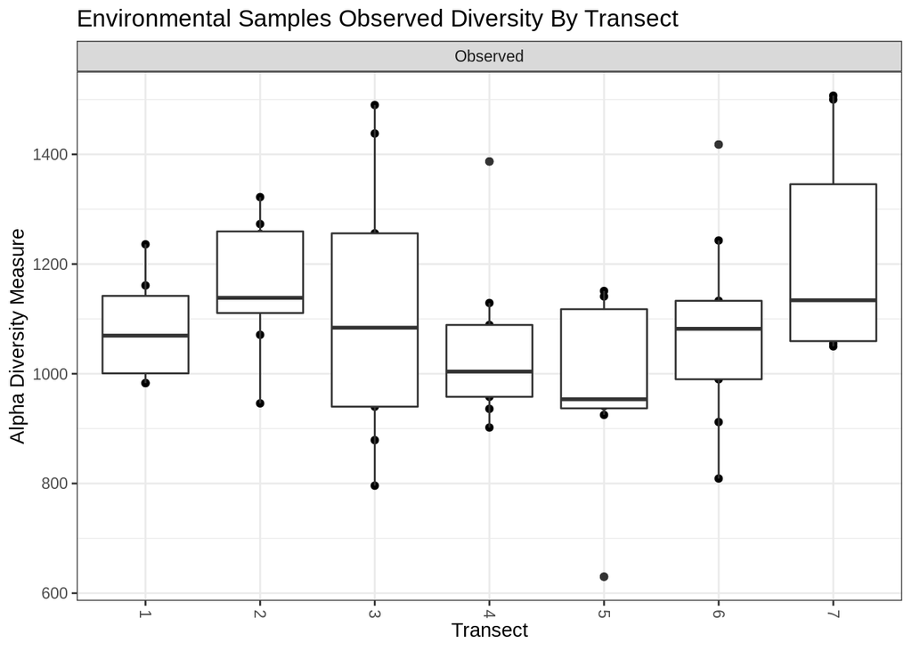

```r
p <- plot_richness(ST_envGroup, x = "transect_name", measures = c("Observed"), title = "Environmental Samples Observed Diversity By Transect")
p + geom_boxplot() + labs(x= "Transect")
```

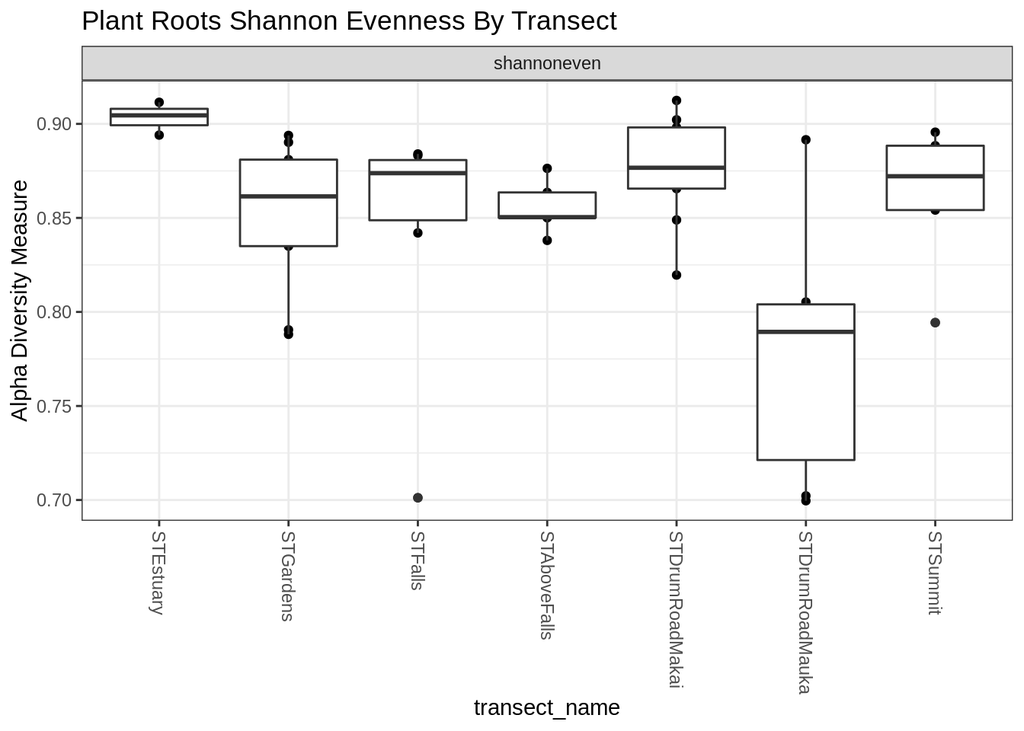

```r
## Plant Samples (taken every 400m, although start and end of transects are closer)
ST_plant <- subset_samples(ST, sample_type == "PlantRoot")
p <- s_plot_richness(ST_plant, x= "transect_name", measures = c("shannoneven"), title = "Plant Roots Shannon Evenness By Transect")
p+geom_boxplot()
```

```r
rm(ST_plant)
```

### Taxa shifts across the gradient

Are bacterial taxa changing in abundance across the gradient? Pull out the most common orders to look at (top 20). Start checking for patterns. Maybe wrap all of this in a function to speed things up.

Will look at this in more detail using linear models.

```r
# top 20 orders
order.sum <- tapply(taxa_sums(ST), tax_table(ST)[, "order"], sum, na.rm = T)
top20 <- sort(order.sum, TRUE)[1:20]
top20
```

```
## Betaproteobacteriales           Rhizobiales         Rickettsiales
##                153661                129779                118672
##         Subgroup_6_or     Enterobacteriales       Chitinophagales
##                 54488                 44866                 34356
##      Sphingomonadales       Acetobacterales          Myxococcales
##                 29901                 28257                 27044
##            Frankiales    Chthoniobacterales      Flavobacteriales
##                 26905                 25460                 22971
##            Gemmatales      Acidobacteriales       Pseudomonadales
##                 22639                 19167                 18820
##            Gaiellales          Cytophagales       Rokubacteriales
##                 17119                 17025                 14761
##       Rhodobacterales        Solibacterales
##                 13826                 13223
```

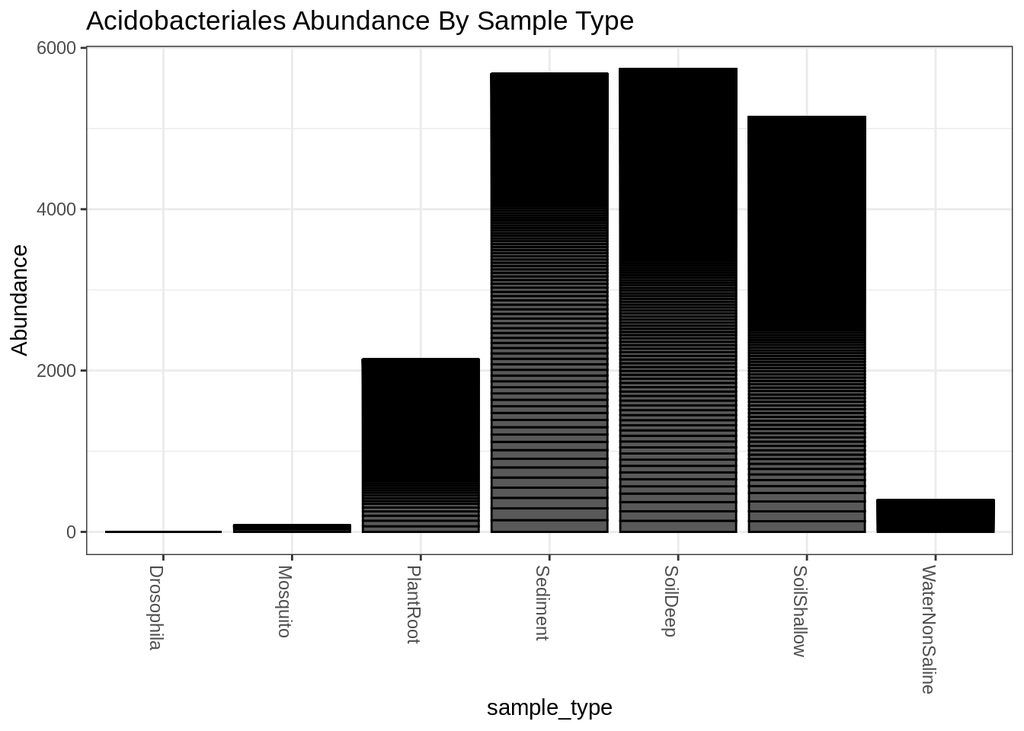

```r
# Check Acidobacteriales since they are mostly in soil and they sound susceptible to pH
ST_acido <-subset_taxa(ST, order == "Acidobacteriales")
plot_bar(ST_acido, x="sample_type",title = "Acidobacteriales Abundance By Sample Type")
```

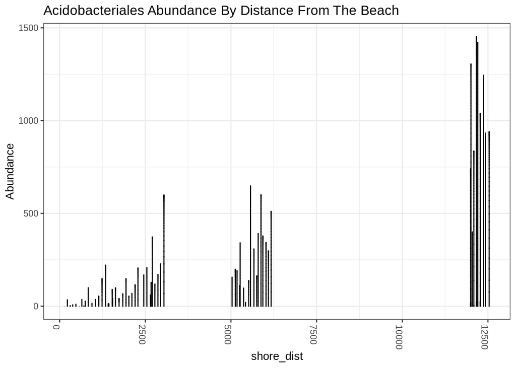

```r
plot_bar(ST_acido , x="shore_dist",title = "Acidobacteriales Abundance By Distance From The Beach")
```